# Species metadata description

# Biodiversity mapping

The following pdf gives a description of the data used in the pipeline run that corresponds to the folder this document resides in. It should be used as a guide for anyone who wants to know more about the data used in the corresponding outputs (maps and datasets) and/or would like to replicate the data.

We begin with basic information about the pipeline run.

| Characteristic | Value |
| --- | --- |
| Date | 2024-10-15 |
| Taxa | vascularPlants |
| Region type | country |
| Region code | Norway |
| Total species | 4693 |
| Total datasets used | 33 |
| DOI | 10.15468/dl.u5q7ne |

In addition to the above, data was downloaded with a maximum uncertainty regarding coordinates of 100 metres.

| taxa | species | redListedSpecies |
| --- | --- | --- |
| vascularPlants | 4693 | 148 |

| dsName | dataType | observations | redListedObservations |
| --- | --- | --- | --- |
| ANOData | PA | 9727740 | 260100 |
| Norwegian Species Observation Service | PO | 2829206 | 71194 |
| Vascular Plants, Observations, Oslo (O) | PA | 1076673 | 124163 |
| Effects of vegetation clearing on vascular plants in power line clearings southeast Norway | PA | 354123 | 1533 |
| Vascular plants in power line clearings and the nearby forest, southeast Norway | PA | 243126 | 2078 |
| Vascular Plants, Field notes, Agder naturmuseum (KMN) | PA | 213355 | 6293 |
| Vascular plant field notes, NTNU University Museum | PA | 208244 | 7600 |
| Overvåking av åpen grunnlendt kalkmark i Oslofjordområdet | PA | 129302 | 6653 |
| Jordal | PO | 110503 | 1587 |
| Vascular Plant Herbarium, Oslo (O) UiO | PO | 104355 | 3847 |

The following gives species richness for observations across the surveyed region by taxa.

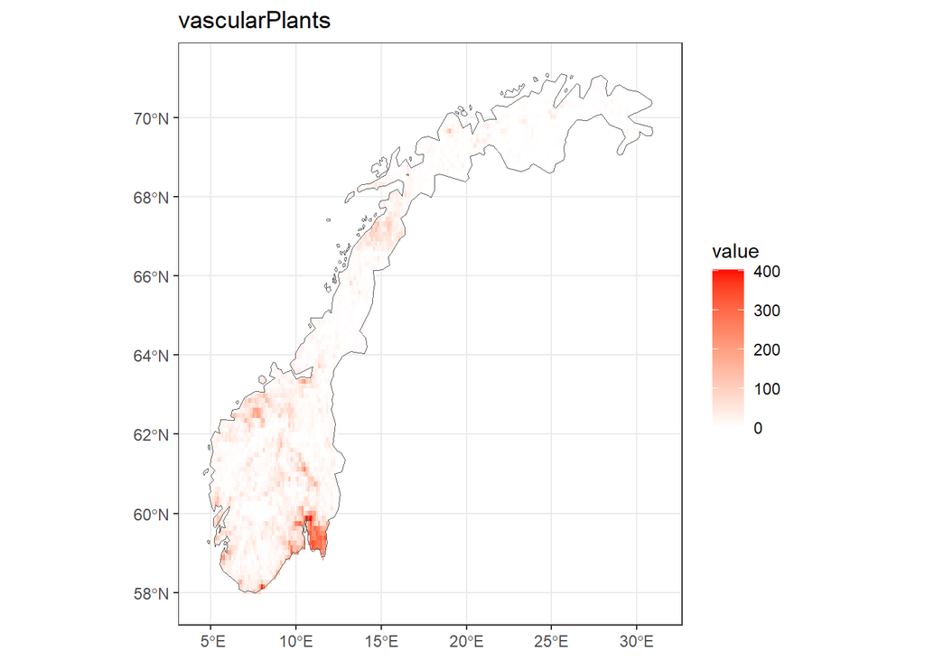

The following gives spatial density for observations across the surveyed region by taxa.

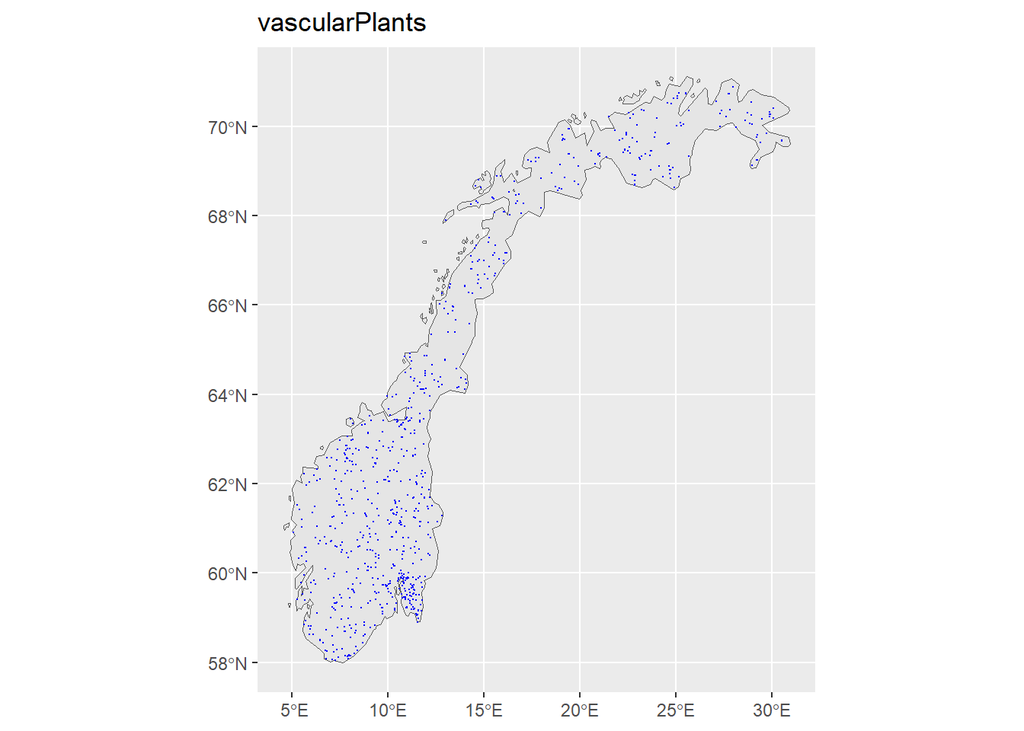

## Appendices

### Appendix 1

The tables below give further information on the observations used for our pipeline run.

Total numbers of observations used in pipeline run for each dataset by taxa.

| taxa | dsName | Observations |
| --- | --- | --- |
| vascularPlants | ANOData | 9727740 |
| vascularPlants | Norwegian Species Observation Service | 2829206 |
| vascularPlants | Vascular Plants, Observations, Oslo (O) | 1076673 |
| vascularPlants | Effects of vegetation clearing on vascular plants in power line clearings southeast Norway | 354123 |
| vascularPlants | Vascular plants in power line clearings and the nearby forest, southeast Norway | 243126 |
| vascularPlants | Vascular Plants, Field notes, Agder naturmuseum (KMN) | 213355 |
| vascularPlants | Vascular plant field notes, NTNU University Museum | 208244 |
| vascularPlants | Overvåking av åpen grunnlendt kalkmark i Oslofjordområdet | 129302 |
| vascularPlants | Jordal | 110503 |
| vascularPlants | Vascular Plant Herbarium, Oslo (O) UiO | 104355 |
| vascularPlants | Overvåking av semi-naturlig eng (ASO) | 101938 |
| vascularPlants | Vegetation data with and without experimental warming, alpine Finse 2000, 2004, 2011 | 101520 |
| vascularPlants | iNaturalist Research-grade Observations | 41360 |
| vascularPlants | Vascular plant herbarium (KMN) UiA | 38214 |
| vascularPlants | Vascular Plants, Field notes, Oslo (O) | 37397 |
| vascularPlants | Vascular plant herbarium TRH, NTNU University Museum | 30613 |
| vascularPlants | Vascular plant herbarium, The Arctic University Museum of Norway (TROM) | 24457 |
| vascularPlants | Observation.org, Nature data from around the World | 23912 |
| vascularPlants | Pl@ntNet automatically identified occurrences | 23766 |
| vascularPlants | Vascular Plant Herbarium, UiB | 15635 |
| vascularPlants | Stabbetorp - Floristiske registreringer 2016 | 10577 |
| vascularPlants | Monitoring data of natural and man-made semi-natural meadows in and around Oslo, Norway 2018-2021 | 9707 |
| vascularPlants | Occurrence data from various smaller projects in Norway | 7793 |
| vascularPlants | Artportalen | 5001 |
| vascularPlants | Pl@ntNet observations | 2221 |
| vascularPlants | ARKO strandeng | 1671 |
| vascularPlants | Vascular Plants, Museum of Archaeology, University of Stavanger | 1089 |
| vascularPlants | Ecofact | 586 |
| vascularPlants | Hatikka.fi observations | 206 |
| vascularPlants | naturgucker | 154 |
| vascularPlants | Norwegian Biodiversity Information Centre - Other datasets | 141 |
| vascularPlants | Norwegian specimens stored in Herb. Klepsland (pre 2022) | 85 |
| vascularPlants | Insects of the Forest-Tundra Ecotone (ForTunE) | 67 |

Total numbers of observations used in pipeline run for each data type by taxa.

| taxa | dataType | Observations |
| --- | --- | --- |
| vascularPlants | PA | 12203125 |
| vascularPlants | PO | 3271612 |